# POLI 178 - Final Project R Code

Andrew Acosta, Daniel Barquero, Raymond Gazzo, Yan Graf, Ryan Liao, Jeffrey Liu, Raphael Reaport, Calli Tullis, and Crystal Zhan

2022-12-04

# Preliminaries

```r
# loading packages
rm(list=ls(all=TRUE))
library(caret)
library(countrycode)
library(ggrepel)
library(ggthemes)
library(gridExtra)
library(kableExtra)
library(lubridate)
library(plyr)
library(rattle)
library(RColorBrewer)
library(readxl)
library(recipes)
library(rgeos)
library(rnaturalearth)
library(rnaturalearthdata)
library(rsample)
library(sf)
library(tidyverse)
library(viridis)
library(yardstick)
library(zoo)

# setting working directory
setwd("C:/Users/jeffr/Downloads/POLI178/Final_Project/")

# loading raw data files
HDI <- read.csv("data/human-development-index.csv")
arms_import <- read_csv("data/china_arms_imports_tiv.csv")
arms_export <- read_csv("data/china_arms_exports_tiv.csv")
imports_full <- read_excel("data/WITS-Imports-Partner-Country.xlsx")
imports_SSA <- read_excel("data/WITS-Imports-Sub-Saharan-Africa.xlsx")
exports_full <- read_excel("data/WITS-Exports-Partner-Country.xlsx")
exports_SSA <- read_excel("data/WITS-Exports-Sub-Saharan-Africa.xlsx")
FDI <- read.csv("data/China-Global-Investment-Tracker-2022-SPRING-final-1.csv")
Fin_Dipl <- read_excel("data/ChineseFinancialPublicDiplomacyProjectDetails.xlsx")
Intl_Gov_Data <- read_excel("data/Government_Data.xls")
UN_Agree <- read.csv("data/AgreementScoresAll_Jun2022.csv")
IGO_Data <- read.csv("data/dyadic_formatv3.csv") # massive 1.19 GB file
polity <- read_excel("data/p5v2018.xls")
GDP <- read_excel("data/Download-GDPcurrent-USD-countries.xlsx")
resources <- read.csv("data/Total_Natural_Resources_Rents.csv", check.names = FALSE)
```

# Data Wrangling

We want to subset for years after 2000.

```r
## also choosing just columns with year, country, and variable of interest
HDI <- HDI %>% filter(Year >= 2000)

arms_import <- select(arms_import, -c(as.character(1950:1999)))
arms_import <- arms_import[-15,] # remove extraneous empty line
arms_export <- select(arms_export, -c(as.character(1950:1999)))
arms_export <- arms_export[-99,] # remove extraneous empty line
imports <- select(imports_full, c("Partner Name", as.character(2000:2020)))
exports <- select(exports_full, c("Partner Name", as.character(2000:2020)))

UN_Agree <- select(UN_Agree, c("ccode1","ccode2","agree","year")) %>%
  subset(year>=2000) %>%
  subset(ccode1 == "710") # filtering for rows relating to China (ccode 710)
IGO_Data <- subset(IGO_Data, year>=2000)

polity <- select(polity, c("year","country","scode","polity2")) %>%
  filter(year >= 2000)

GDP <- select(GDP, c("Country", "IndicatorName",as.character(2000:2020)))

resources <- select(resources, c("Country Name", "Country Code",as.character(2000:2020)))
```

## Variable-Specific Wrangling

### Arms Imports/Exports

```r
# handle missingness by defaulting to 0 imports/exports
arms_import[is.na(arms_import)] <- 0
arms_export[is.na(arms_export)] <- 0

# rename country column
names(arms_import)[names(arms_import) == "...1"] <- "Country"
names(arms_export)[names(arms_export) == "...1"] <- "Country"
```

### Foreign Direct Investment

```r
# drop unnecessary columns
FDI <- select(FDI, -c("Investor", "Share.Size", "Transaction.Party", "Subsector", "Region", "Greenfield", "Month"))

# convert dollar amounts into numeric format
FDI[]<-lapply(FDI,gsub,pattern="$",fixed=TRUE,replacement="")
FDI[]<-lapply(FDI,gsub,pattern=",",fixed=TRUE,replacement="")
FDI$Quantity.in.Millions <- as.numeric(FDI$Quantity.in.Millions)

# convert BRI column into numeric format
FDI$BRI <- as.numeric(FDI$BRI)

# missingness treated as default 0 (not related to BRI)
FDI <- FDI %>% replace(is.na(.), 0)

# create new dataframe for country resolution data (total investment over 2005-2022)
FDI_country_all_time <- data.frame(matrix(ncol = 2, nrow = length(unique(c(FDI$Country)))))
names(FDI_country_all_time) = c("Country","Total.Money.Invested")

# setting column class types
class(FDI_country_all_time$Country) <- "Character"
FDI_country_all_time$Total.Money.Invested <- as.numeric(FDI_country_all_time$Total.Money.Invested)

# put country names in
FDI_country_all_time$Country = unique(c(FDI$Country))

# loop for all countries
for(x in FDI_country_all_time$Country){
  FDI_temp <- FDI %>% filter(FDI$Country == x)
  temp_sum <- sum(as.numeric(FDI_temp[, "Quantity.in.Millions"]))
  row_index <- which(FDI_country_all_time$Country == x)
  FDI_country_all_time[row_index, "Total.Money.Invested"] <- temp_sum
}

# repeat for FDI by country and year
# create new dataframe for country-year resolution data
FDI_country_year <- expand(tibble(), 2005:2022, FDI_country_all_time$Country)
FDI_country_year$Money.Invested <- 0
colnames(FDI_country_year) <- c("Year","Country","Money.Invested")

for(x in FDI_country_all_time$Country){
  for(y in 2005:2022) {
    FDI_temp <- FDI %>% filter(FDI$Country == x & FDI$Year == y)
    temp_sum <- sum(as.numeric(FDI_temp[, "Quantity.in.Millions"]))
    row_index <- which(FDI_country_year$Country == x & FDI_country_year$Year == y)
    FDI_country_year[row_index, "Money.Invested"] <- temp_sum
  }
}

# remove unnecessary variables
FDI <- FDI_country_year
rm(FDI_country_year, FDI_temp, row_index, temp_sum, x, y)
```

### Financial Diplomacy

```r
# convert number strings to numeric values
Fin_Dipl <- Fin_Dipl %>%
  mutate_at(c("commitment_year", "implementation_start_year", "completion_year",
              "sector_code", "amount_original_currency", "amount_constant_usd2017",
              "amount_nominal", "maturity", "interest_rate",    "grace_period", "management_fee",
              "commitment_fee", "grant_element", "source_quality_score",    "data_completeness_score",
              "project_implementation_score",   "loan_detail_score"), as.numeric)

# drop unnecessary columns
Fin_Dipl_full <- Fin_Dipl %>% select(-c("project_id", "recommended_for_research", "umbrella_project",
                                        "title", "description", "staff_comments", "receiving_agencies_origin",
                                        "implementing_agencies_origin", "accountable_agencies_origin",
                                        "planned_implementation_start_date", "planned_completion_date",
                                        "official_source_count",    "unofficial_source_count", "source_urls",
                                        "source_titles",    "source_publishers",    "source_type", "location_details",
                                        "geojson_url_viz",  "geojson_url_dl", "contact_name",   "contact_position",
                                        "oda_eligible_recipient"))

# converting data into country-year resolution
# get relevant columns and remove rows without amount given
Fin_Dipl <- select(Fin_Dipl_full, c("recipient","commitment_year","amount_nominal"))
Fin_Dipl <- Fin_Dipl[!is.na(Fin_Dipl$amount_nominal), 1:3]

# get list of all countries and years
Fin_Dipl_countries <- unique(Fin_Dipl$recipient)
Fin_Dipl_years <- 2000:2017
Fin_Dipl_country_year <- expand(tibble(), Fin_Dipl_years, Fin_Dipl_countries)
Fin_Dipl_country_year$amount <- NA

# iterate and sum for total financial diplomatic investment in all countries and years
for(i in Fin_Dipl_countries){
  for(j in 2000:2017) {
    Fin_Dipl_subset <- Fin_Dipl %>% filter(Fin_Dipl$recipient == i & Fin_Dipl$commitment_year == j)
    country_year_sum <- sum(Fin_Dipl_subset[, 3])
    row_index <- which(Fin_Dipl_country_year$Fin_Dipl_countries == i & Fin_Dipl_country_year$Fin_Dipl_years == j)
    Fin_Dipl_country_year[row_index, 3] <- as.numeric(country_year_sum)
  }
}

# rename columns
colnames(Fin_Dipl_country_year) <- c("Year", "Country", "Fin.Diplomacy")

# remove unnecessary variables
Fin_Dipl <- Fin_Dipl_country_year
rm(Fin_Dipl_countries, Fin_Dipl_years, Fin_Dipl_country_year, Fin_Dipl_subset, country_year_sum, row_index)
```

### UN Agreement

```r
# matching UN_Agree country codes to country names
UN_Agree$ccode2 <- as.character(UN_Agree$ccode2) # recode to character

# create df with ccode and country name conversion
country_code <- data.frame(Intl_Gov_Data$ccode, Intl_Gov_Data$country, Intl_Gov_Data$un_continent,
                           Intl_Gov_Data$un_region)
country_code <- distinct(country_code)
country_code <- country_code %>% rename(ccode2 = Intl_Gov_Data.ccode,
                                        country = Intl_Gov_Data.country,
                                        un_continent = Intl_Gov_Data.un_continent,
                                        un_region = Intl_Gov_Data.un_region)

# merge to get conversion between code and country
UN_Agree <- merge(UN_Agree, country_code, by = "ccode2")
```

### IGO Participation

```r
# select rows with CHN involved
China_IGO1 <- subset(IGO_Data, country1 == "CHN")
China_IGO2 <- subset(IGO_Data, country2 == "CHN")

# reorder so China is always first country
China_IGO2 <- rename(China_IGO2, country1 = country2, country2 = country1, ccode1 = ccode2, ccode2 = ccode1)

# combine to one big dataframe
China_IGO <- rbind(China_IGO1, China_IGO2)
China_IGO <- merge(China_IGO, country_code, by = "ccode2")

# first subset for only IGO participation columns
IGO_Dummy <- China_IGO[c(7:540)]

# handle missingness by defaulting to 0 (not participating)
IGO_Dummy <- replace(IGO_Dummy, IGO_Dummy < 0, 0)

# calculate alignment score based on mutual participation
alignment <- rowSums(IGO_Dummy)
IGO <- data.frame(China_IGO, alignment)
IGO$alignment <- IGO$alignment/max(alignment)

# remove unnecessary variables
rm(alignment, China_IGO, China_IGO1, China_IGO2, country_code, IGO_Data, IGO_Dummy, Intl_Gov_Data, i, j)
```

### GDP

```r
# subset for just GDP rows
GDP <- GDP %>% subset(IndicatorName == "Gross Domestic Product (GDP)")
```

## Country Codes

We want to add country codes to ensure matches across datasets. We will manually do this if needed.

```r
arms_import$Code <- countrycode(arms_import$Country, "country.name", "iso3c")
arms_export$Code <- countrycode(arms_export$Country, "country.name", "iso3c")
imports$Code <- countrycode(imports$`Partner Name`, "country.name", "iso3c")
imports$Code[which(imports$'Partner Name' == "Czechoslovakia")] <- 'CSK'
imports$Code[which(imports$'Partner Name' == "Ethiopia(excludes Eritrea)")] <- 'ETH'
imports$Code[which(imports$'Partner Name' == "Netherlands Antilles")] <- 'ANT'
imports$Code[which(imports$'Partner Name' == "Occ.Pal.Terr")] <- 'PSE'
imports$Code[which(imports$'Partner Name' == "Serbia, FR(Serbia/Montenegro)")] <- 'SCG'

exports$Code <- countrycode(exports$`Partner Name`, "country.name", "iso3c")
exports$Code[which(exports$'Partner Name' == "Czechoslovakia")] <- 'CSK'
exports$Code[which(exports$'Partner Name' == "Ethiopia(excludes Eritrea)")] <- 'ETH'
exports$Code[which(exports$'Partner Name' == "Netherlands Antilles")] <- 'ANT'
exports$Code[which(exports$'Partner Name' == "Occ.Pal.Terr")] <- 'PSE'
exports$Code[which(exports$'Partner Name' == "Serbia, FR(Serbia/Montenegro)")] <- 'SCG'

FDI$Code <- countrycode(FDI$Country, "country.name", "iso3c")
FDI_country_all_time$Code <- countrycode(FDI_country_all_time$Country, "country.name", "iso3c")

Fin_Dipl$Code <- countrycode(Fin_Dipl$Country, "country.name", "iso3c")
Fin_Dipl$Code[which(Fin_Dipl$Country == "Micronesia")] <- 'FSM'

IGO$Code <- countrycode(IGO$country, "country.name", "iso3c")
IGO$Code[which(IGO$country == "Serbia and Montenegro")] <- 'SCG'
IGO$Code[which(IGO$country == "Yugoslavia")] <- 'YGS'

UN_Agree$Code <- countrycode(UN_Agree$country, "country.name", "iso3c")
UN_Agree$Code[which(UN_Agree$country == "Yugoslavia")] <- 'YGS'

polity$Code <- countrycode(polity$scode, "p4c", "iso3c")
polity$Code[which(polity$scode == "SUD")] <- 'SDN'
polity$Code[which(polity$scode == "YGS")] <- 'YUG'

GDP$Code <- countrycode(GDP$Country, "country.name", "iso3c")
GDP$Code[which(GDP$Country == "Czechoslovakia (Former)")] <- 'CSK'
GDP$Code[which(GDP$Country == "Former Netherlands Antilles")] <- 'ANT'
GDP$Code[which(GDP$Country == "Micronesia (FS of)")] <- 'FSM'
GDP$Code[which(GDP$Country == "Yemen Arab Republic (Former)")] <- 'YEM'
GDP$Code[which(GDP$Country == "Yugoslavia (Former)")] <- 'YUG'
GDP$Code[which(GDP$Country == "Zanzibar")] <- 'EAZ'
```

## Further Wrangling

```r
# standardizing dollar amounts
imports[, c(as.character(2000:2020))] <- imports[, c(as.character(2000:2020))] * 1000
exports[, c(as.character(2000:2020))] <- exports[, c(as.character(2000:2020))] * 1000
FDI$Money.Invested <- FDI$Money.Invested * 1000000

# pivoting to country-year resolution
arms_import <- pivot_longer(arms_import, as.character(2000:2021), names_to = "Year", values_to = "Arms.Imports")
arms_export <- pivot_longer(arms_export, as.character(2000:2021), names_to = "Year", values_to = "Arms.Exports")
imports <- pivot_longer(imports, as.character(2000:2020), names_to = "Year", values_to = "Imports")
exports <- pivot_longer(exports, as.character(2000:2020), names_to = "Year", values_to = "Exports")
GDP <- pivot_longer(GDP, as.character(2000:2020), names_to = "Year", values_to = "GDP")
resources <- pivot_longer(resources, as.character(2000:2020), names_to = "Year", values_to = "Resources")

# set Year to be numeric
arms_import$Year <- as.numeric(arms_import$Year)
arms_export$Year <- as.numeric(arms_export$Year)
imports$Year <- as.numeric(imports$Year)
exports$Year <- as.numeric(exports$Year)
GDP$Year <- as.numeric(GDP$Year)
resources$Year <- as.numeric(resources$Year)

# getting totals for each country in arms imports/exports
arms_import_w_total <- arms_import[!is.na(arms_import$Code),] %>%
  select(-c("Year","Arms.Imports")) %>%
  distinct()
arms_export_w_total <- arms_export[!is.na(arms_export$Code),] %>%
  select(-c("Year","Arms.Exports")) %>%
  distinct()

# removing no-match rows and renaming columns
HDI <- HDI[HDI$Code != "",]
colnames(HDI) <- c("Country", "Code", "Year", "HDI")

imports <- imports[!is.na(imports$Code),]
exports <- exports[!is.na(exports$Code),]

colnames(FDI) <- c("Year", "Country", "FDI", "Code")

UN_Agree <- UN_Agree[!is.na(UN_Agree$Code),c("agree","year","country","Code")] # selecting relevant portions
colnames(UN_Agree) <- c("UN.Agreement", "Year", "Country", "Code")
IGO <- IGO[!is.na(IGO$Code),c("year","country","alignment","Code")] # selecting relevant portions
colnames(IGO) <- c("Year", "Country", "IGO.Alignment", "Code")

polity <- select(polity, -scode)
polity <- polity[!is.na(polity$Code),]
colnames(polity) <- c("Year", "Country", "Polity", "Code")

colnames(GDP) <- c("Country", "Indicator.Name", "Code", "Year", "GDP")

resources <- resources[!is.na(resources$`Country Code`),]
colnames(resources) <- c("Country", "Code", "Year", "Resources")

# reduce all variables to have just year, code, and variable
HDI <- select(HDI, c("Year", "Code", "HDI"))
arms_import <- select(arms_import, c("Year", "Code", "Arms.Imports"))
arms_export <- select(arms_export, c("Year", "Code", "Arms.Exports"))
imports <- select(imports, c("Year", "Code", "Imports"))
exports <- select(exports, c("Year", "Code", "Exports"))
FDI <- select(FDI, c("Year", "Code", "FDI"))
Fin_Dipl <- select(Fin_Dipl, c("Year", "Code", "Fin.Diplomacy"))
IGO <- select(IGO, c("Year", "Code", "IGO.Alignment"))
UN_Agree <- select(UN_Agree, c("Year", "Code", "UN.Agreement"))
polity <- select(polity, c("Year", "Code", "Polity"))
GDP <- select(GDP, c("Year", "Code", "GDP"))
resources <- select(resources, c("Year", "Code", "Resources"))
```

## The Merged Dataset. At Last.

```r
# merge time
merge_list <- list(HDI, arms_import, arms_export, imports, exports, FDI, Fin_Dipl,
                   IGO, UN_Agree, polity, GDP, resources)
df <- merge_list %>% reduce(full_join, by=c("Year", "Code"))
df$Year <- as.character(df$Year)
head(df)
```

```
##   Year Code   HDI Arms.Imports Arms.Exports Imports  Exports FDI Fin.Diplomacy
## 1 2000  AFG 0.335           NA            0 5395751 19891090  NA        500000
## 2 2000  AFG 0.335           NA            0 5395751 19891090  NA        500000
## 3 2001  AFG 0.337           NA            0  161597 17265197  NA       1120815
## 4 2001  AFG 0.337           NA            0  161597 17265197  NA       1120815
## 5 2002  AFG 0.362           NA            0   79936 19910993  NA       7195107
## 6 2002  AFG 0.362           NA            0   79936 19910993  NA       7195107
##   IGO.Alignment UN.Agreement Polity        GDP Resources
## 1     0.3802817    0.9545455     -7 3342034168        NA
## 2     0.3802817    0.9545455     -7 3342034168        NA
## 3     0.3802817    0.9021739     NA 3598470576        NA
## 4     0.3802817    0.9021739     NA 3598470576        NA
## 5     0.3802817    0.9117647     NA 4141523943  1.024958
## 6     0.3802817    0.9117647     NA 4141523943  1.024958
```

```r
# save df to save computation time for future use
write.csv(df, "output/FINAL_DATASET.csv", row.names = FALSE)
```

# Data Exploration

## HDI Score

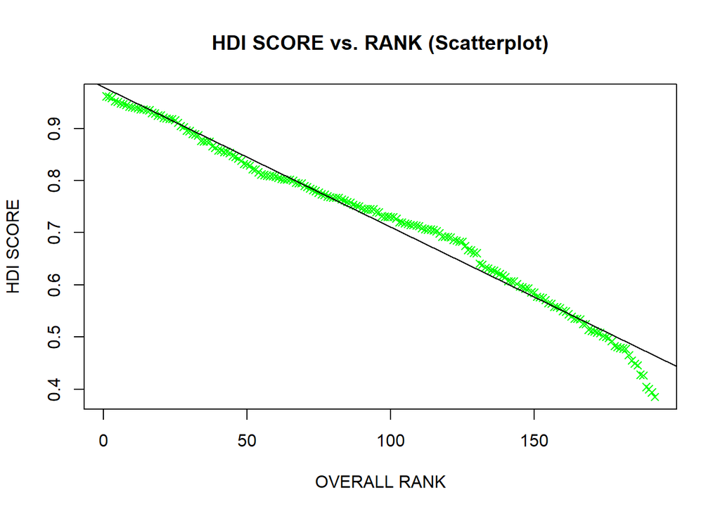

```r
# get 2021 data and rank them
HDI_2021 <- HDI %>% filter(Year == "2021")
HDI_2021$rank <- rank(-HDI_2021$HDI, ties.method = "first")

# Scatterplot
plot(x = HDI_2021$rank, y = HDI_2021$HDI,
     xlab = "OVERALL RANK", ylab = "HDI SCORE", col = "green",
     pch = 4, main = "HDI SCORE vs. RANK (Scatterplot)")

abline(lm(HDI ~ rank, data = HDI_2021), col = "black")
```

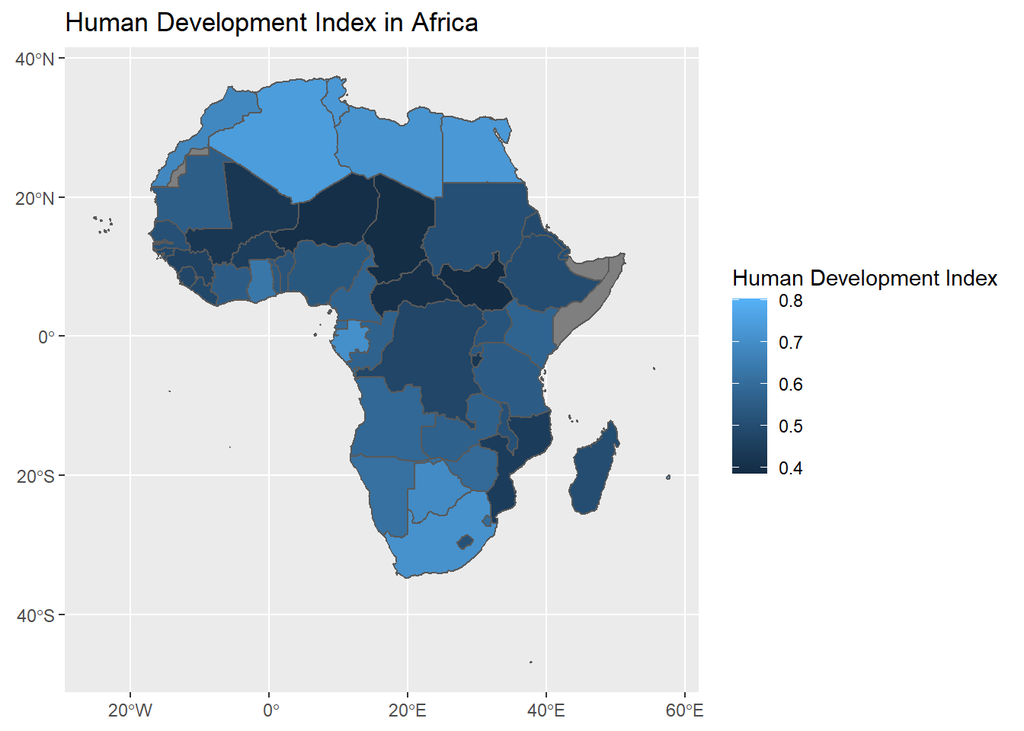

```r
# Geospatial: Africa
# first get world map
world <- ne_countries(scale = "medium", returnclass = "sf")

# then just Africa
AFR_sf <- world %>% filter(region_un == "Africa")

AFR_sf <- merge(AFR_sf, HDI_2021, by.x = "iso_a3", by.y = "Code", all.x = TRUE)

ggplot(data=AFR_sf, aes(fill = HDI)) +
  scale_fill_gradientn(colours = c("#132B43", "#56B1F7"),
                       name = "Human Development Index") +
  geom_sf() + ggtitle("Human Development Index in Africa")
```

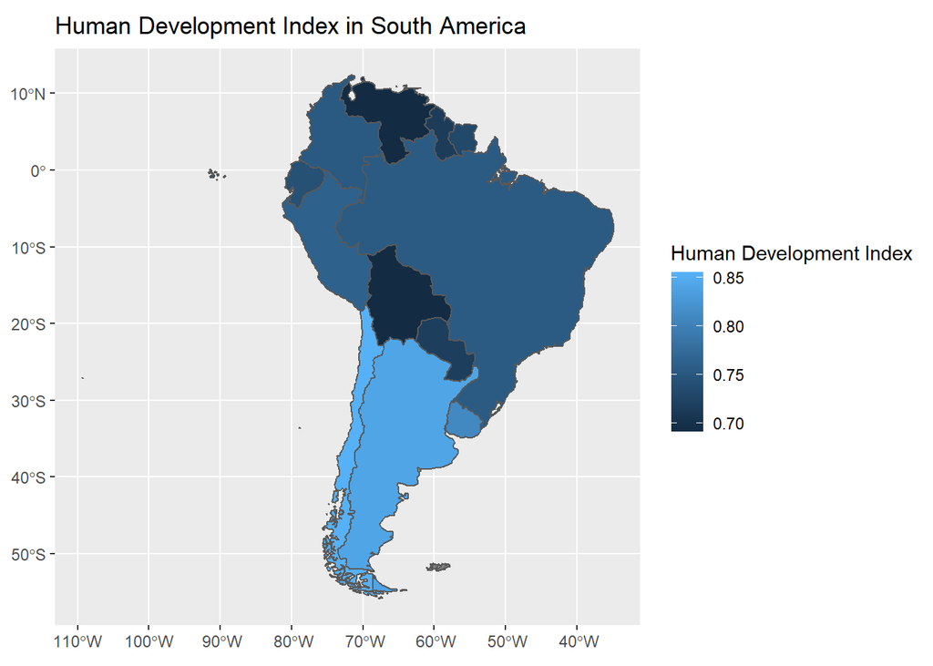

```r
# Geospatial: South America
# now get just South America
SA_sf <- world %>% filter(continent == 'South America')

SA_sf <- merge(SA_sf, HDI_2021, by.x = "iso_a3", by.y = "Code", all.x = TRUE)

ggplot(data=SA_sf, aes(fill = HDI)) +
  scale_fill_gradientn(colours = c("#132B43", "#56B1F7"),
                       name = "Human Development Index") +
  geom_sf() + ggtitle("Human Development Index in South America")
```

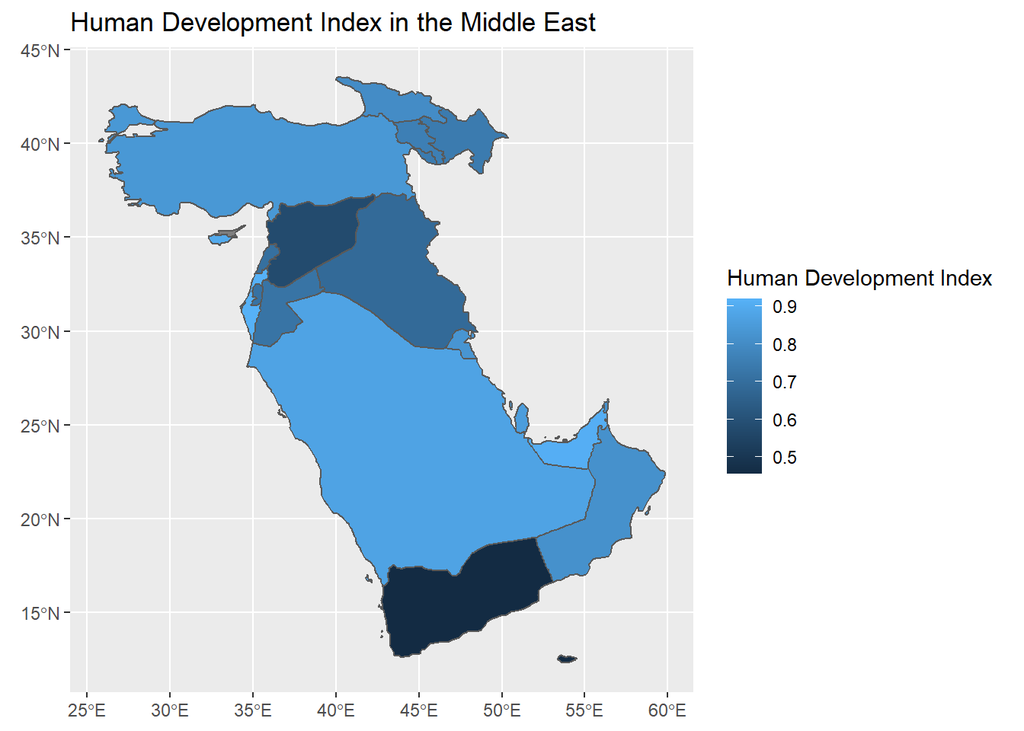

```r
# Geospatial: Middle East
# now get just Middle East
ME_sf <- world %>% filter(subregion == 'Western Asia')

ME_sf <- merge(ME_sf, HDI_2021, by.x = "iso_a3", by.y = "Code", all.x = TRUE)

ggplot(data=ME_sf, aes(fill = HDI)) +
  scale_fill_gradientn(colours = c("#132B43", "#56B1F7"),
                       name = "Human Development Index") +
  geom_sf() + ggtitle("Human Development Index in the Middle East")
```

## Trade: Arms Imports

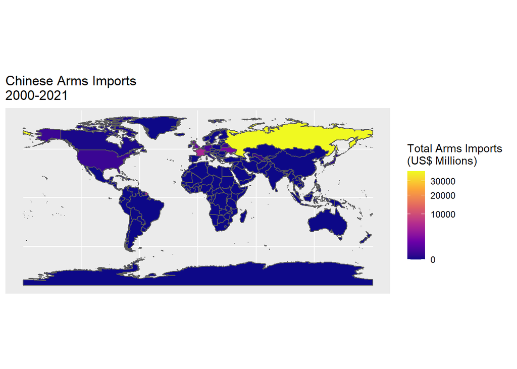

```r
# get dataframe with arms imports
arms_import_geo <- merge(world, arms_import_w_total, by.x = "iso_a3", by.y = "Code", all=TRUE)

# missing data assumed to mean no arms imports
arms_import_geo[is.na(arms_import_geo$Total),"Total"] <- 0

# geospatial
ggplot(data = arms_import_geo) +
  geom_sf(aes(fill = Total)) +
  scale_fill_viridis_c(option = "plasma", trans = "sqrt") +
  labs(title = "Chinese Arms Imports \n2000-2021", fill = "Total Arms Imports \n(US$ Millions)")
```

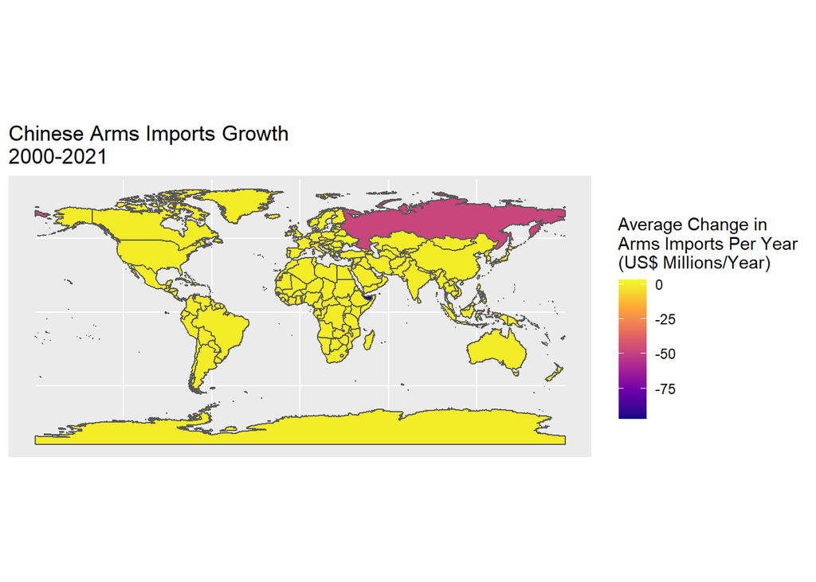

```r
# use linear regression to see trend in arms imports
# and get coefficients
arms_import_models <- dlply(arms_import, "Code", function(df)
  lm(Arms.Imports ~ Year, data = df))
arms_import_coefficients <- ldply(arms_import_models, coef)

# geospatial for growth
arms_import_reg_geo <- merge(world, arms_import_coefficients, by.x = "iso_a3", by.y = "Code", all=TRUE)
arms_import_reg_geo[is.na(arms_import_reg_geo)] <- 0

ggplot(data = arms_import_reg_geo) +
  geom_sf(aes(fill = Year)) +
  scale_fill_viridis_c(option = "plasma") +
  labs(title = "Chinese Arms Imports Growth \n2000-2021",
       fill = "Average Change in \nArms Imports Per Year\n(US$ Millions/Year)")
```

## Trade: Arms Exports

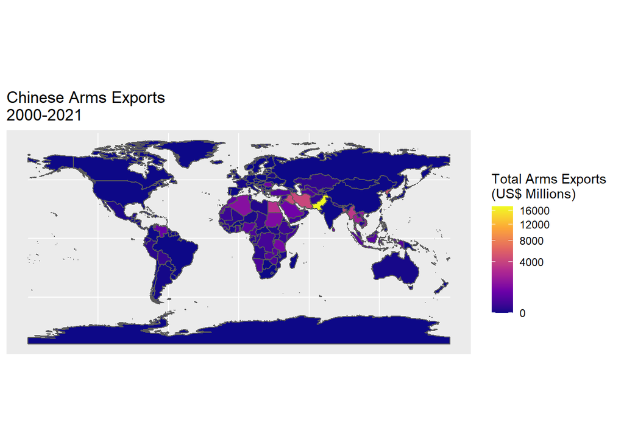

```r
# get dataframe with arms exports
arms_export_geo <- merge(world, arms_export_w_total, by.x = "iso_a3", by.y = "Code", all=TRUE)

# missing data assumed to mean no arms exports
arms_export_geo[is.na(arms_export_geo$Total),"Total"] <- 0

# geospatial
ggplot(data = arms_export_geo) +
  geom_sf(aes(fill = Total)) +
  scale_fill_viridis_c(option = "plasma", trans = "sqrt") +
  labs(title = "Chinese Arms Exports \n2000-2021", fill = "Total Arms Exports \n(US$ Millions)")
```

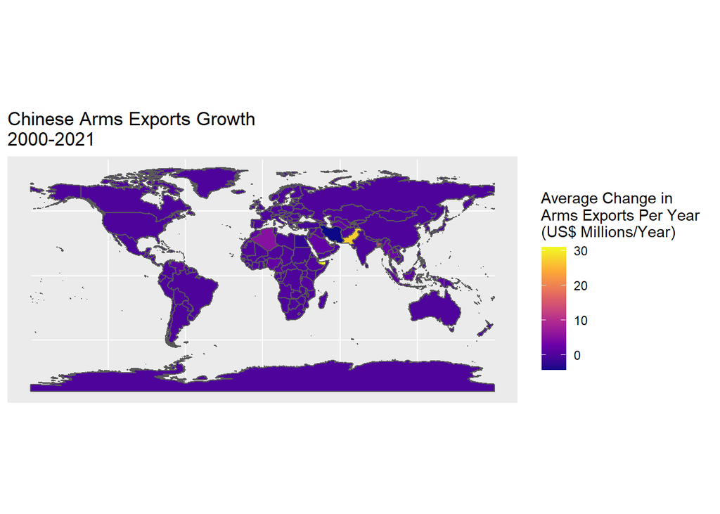

```r
# use linear regression to see trend in arms exports
# and get coefficients
arms_export_models <- dlply(arms_export, "Code", function(df)
  lm(Arms.Exports ~ Year, data = df))
arms_export_coefficients <- ldply(arms_export_models, coef)

# geospatial for growth
arms_export_reg_geo <- merge(world, arms_export_coefficients, by.x = "iso_a3", by.y = "Code", all=TRUE)
arms_export_reg_geo[is.na(arms_export_reg_geo)] <- 0

ggplot(data = arms_export_reg_geo) +
  geom_sf(aes(fill = Year)) +
  scale_fill_viridis_c(option = "plasma") +
  labs(title = "Chinese Arms Exports Growth \n2000-2021",
       fill = "Average Change in \nArms Exports Per Year \n(US$ Millions/Year)")
```

## Trade: Imports

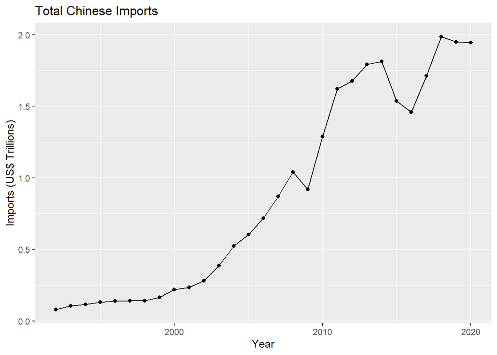

```r
# get total imports by year
imports_year <- colSums(imports_full[, as.character(1992:2020)], na.rm = TRUE)
imports_year <- data.frame(1992:2020, imports_year/10^9)
colnames(imports_year) <- c("Year", "Total.Imports")

ggplot(imports_year, aes(x = Year, y = Total.Imports))+
  geom_line(aes(group=1)) +
  geom_point() +
  labs(title = "Total Chinese Imports", x = "Year", y = "Imports (US$ Trillions)")
```

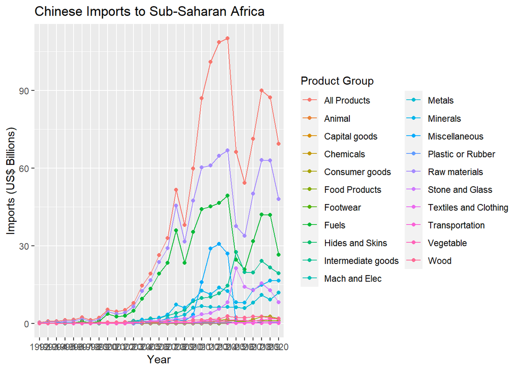

```r
# Sub-Saharan Africa imports
# get important columns
imports_SSA <- select(imports_SSA, c("Product Group", as.character(1992:2020)))

# pivot for graphing
imports_SSA <- imports_SSA %>%
  pivot_longer(!`Product Group`, names_to = "Year", values_to = "Imports")

ggplot(imports_SSA, aes(x = Year, y = Imports/10^6,
                        color = `Product Group`, group = `Product Group`)) +
  geom_point() +
  geom_line() +
  labs(title = "Chinese Imports to Sub-Saharan Africa", x = "Year",
       y = "Imports (US$ Billions)", color = "Product Group")
```

## Trade: Exports

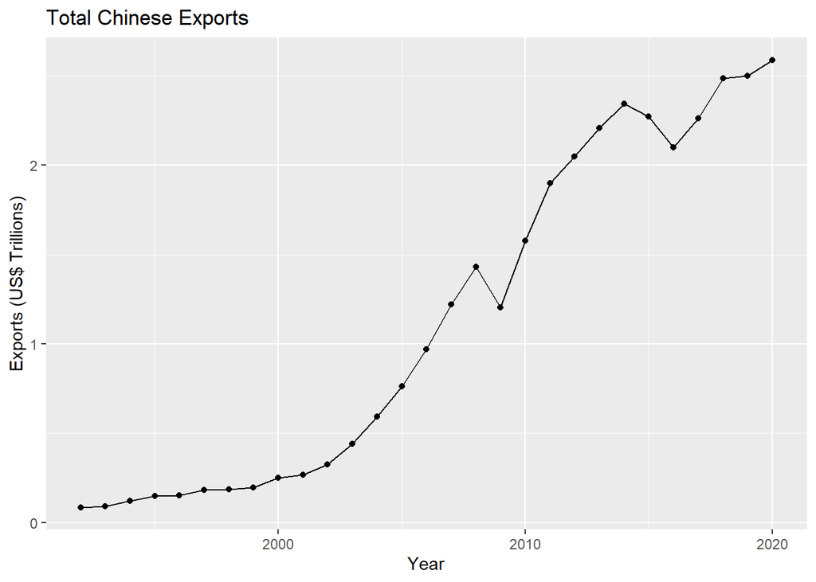

```r
# get total exports by year
exports_year <- colSums(exports_full[, as.character(1992:2020)], na.rm = TRUE)
exports_year <- data.frame(1992:2020, exports_year/10^9)
colnames(exports_year) <- c("Year", "Total.Exports")

ggplot(exports_year, aes(x = Year, y = Total.Exports))+
  geom_line(aes(group=1)) +
  geom_point() +
  labs(title = "Total Chinese Exports", x = "Year", y = "Exports (US$ Trillions)")
```

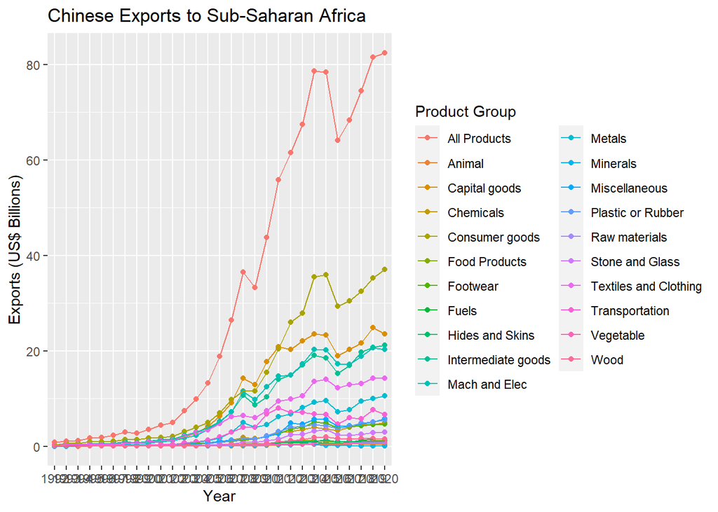

```r
# Sub-Saharan Africa exports
# get important columns
exports_SSA <- select(exports_SSA, c("Product Group", as.character(1992:2020)))

# pivot for graphing
exports_SSA <- exports_SSA %>%
  pivot_longer(!`Product Group`, names_to = "Year", values_to = "Exports")

ggplot(exports_SSA, aes(x = Year, y = Exports/10^6,
                        color = `Product Group`, group = `Product Group`)) +
  geom_point() +
  geom_line() +
  labs(title = "Chinese Exports to Sub-Saharan Africa", x = "Year",
       y = "Exports (US$ Billions)", color = "Product Group")
```

## Foreign Direct Investment

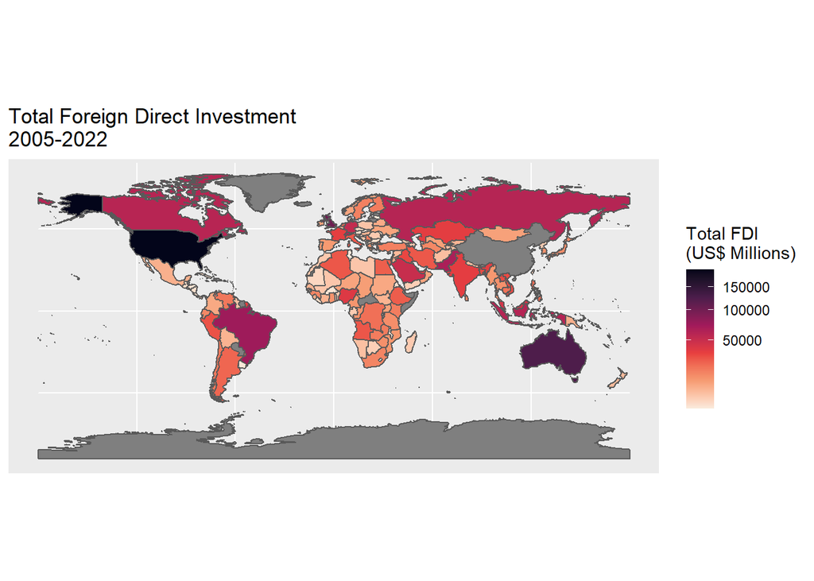

```r
# normalize FDI by current GDP
GDP_2020 <- subset(GDP, Year == "2020")
GDP_2020 <- GDP_2020[!is.na(GDP_2020$GDP),]
FDI_country_all_time <- left_join(FDI_country_all_time, GDP_2020, by = "Code")
FDI_country_all_time$Normalized.FDI <- FDI_country_all_time$Total.Money.Invested / FDI_country_all_time$GDP * 10^6

# geospatial, unnormalized
FDI_geo <- merge(world, FDI_country_all_time, by.x = "iso_a3", by.y = "Code", all.x = TRUE)
ggplot(data = FDI_geo) +
  geom_sf(aes(fill = Total.Money.Invested)) +
  scale_fill_viridis_c(option = "rocket", trans = "sqrt", direction = -1) +
  labs(title = "Total Foreign Direct Investment \n2005-2022",
       fill = "Total FDI \n(US$ Millions)")
```

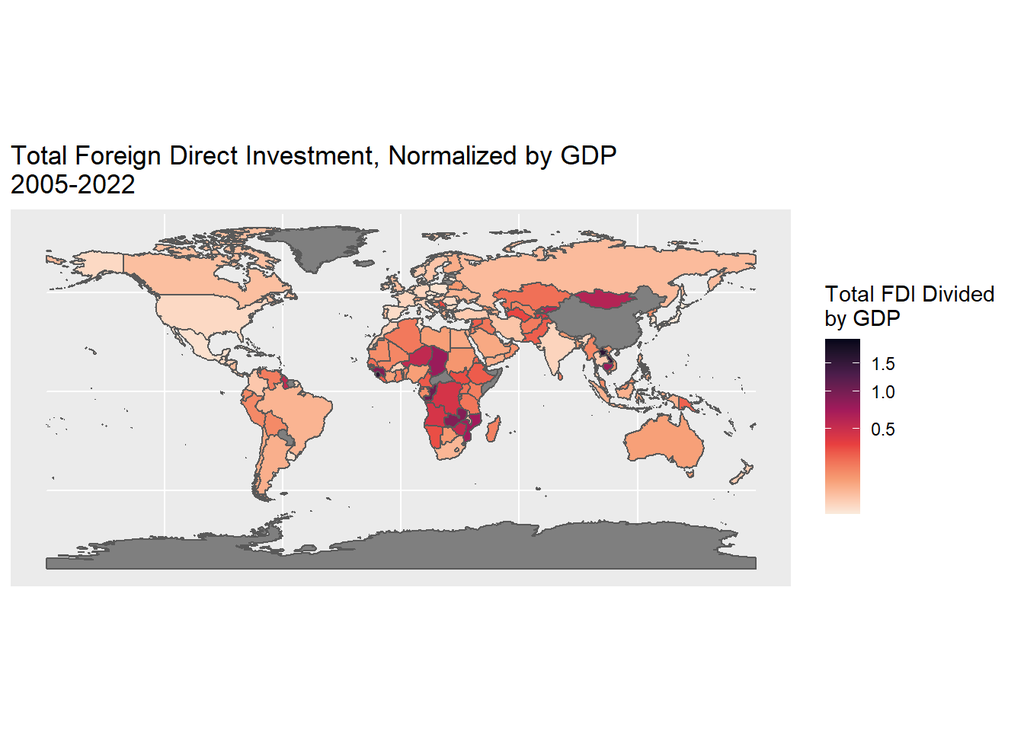

```r
# geospatial, normalized
ggplot(data = FDI_geo) +
  geom_sf(aes(fill = Normalized.FDI)) +
  scale_fill_viridis_c(option = "rocket", trans = "sqrt", direction = -1) +
  labs(title = "Total Foreign Direct Investment, Normalized by GDP \n2005-2022",
       fill = "Total FDI Divided \nby GDP")
```

## Financial Diplomacy

[figure not shown]

```r
# visualize financial diplomacy
# bar graph of how many times a country has received financial diplomacy
ggplot(Fin_Dipl_full, aes(x=recipient)) +
  geom_bar()
```

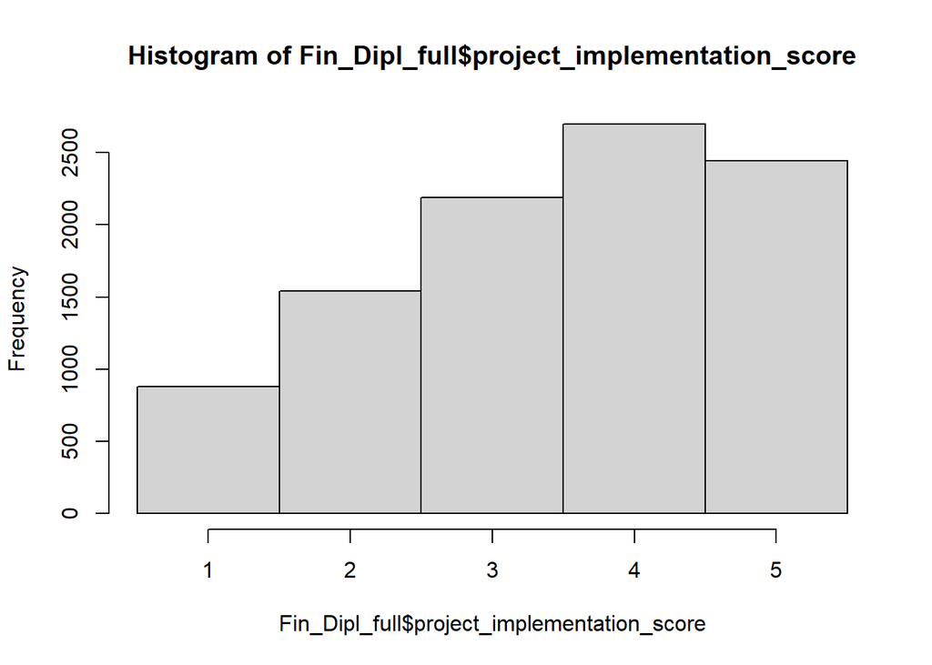

```r
# histogram of project implementation scores
hist(Fin_Dipl_full$project_implementation_score, breaks = 0.5:5.5)
```

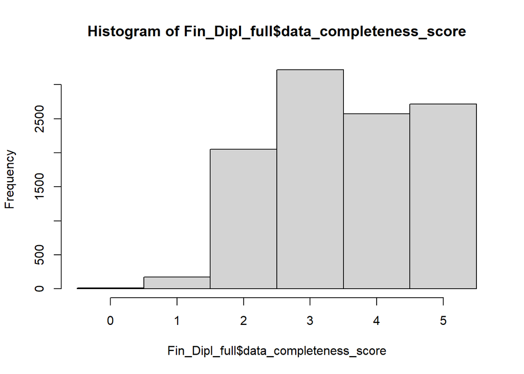

```r
# histogram of how complete the data are
hist(Fin_Dipl_full$data_completeness_score, breaks = -0.5:5.5)
```

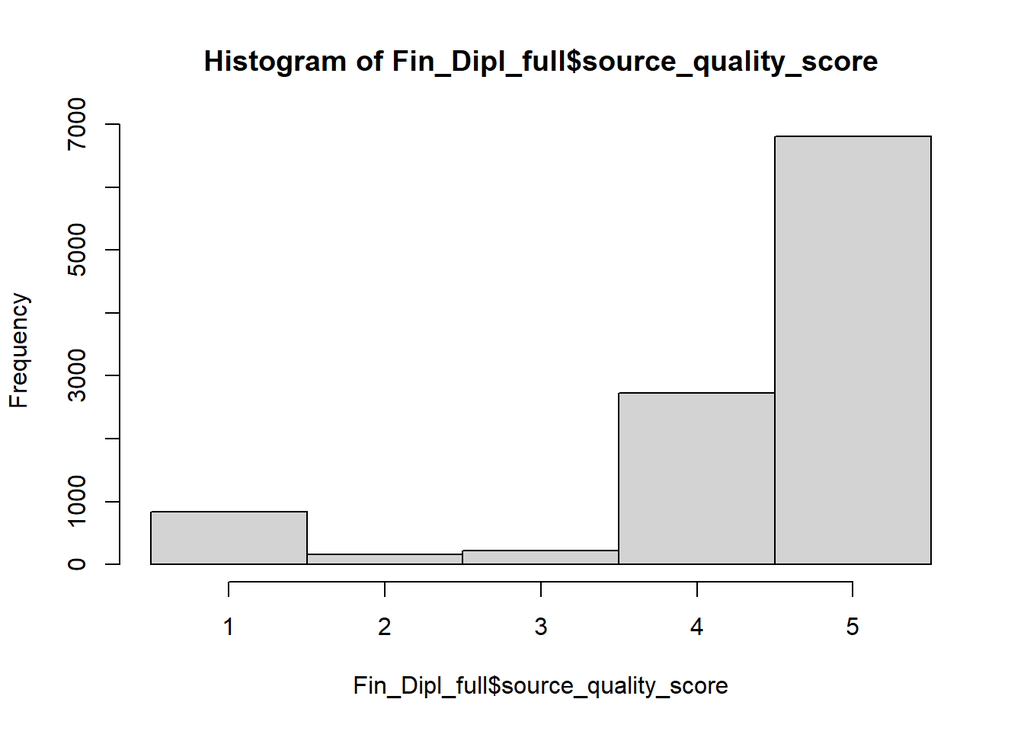

```r
# histogram of the quality of the source
hist(Fin_Dipl_full$source_quality_score, breaks = 0.5:5.5)
```

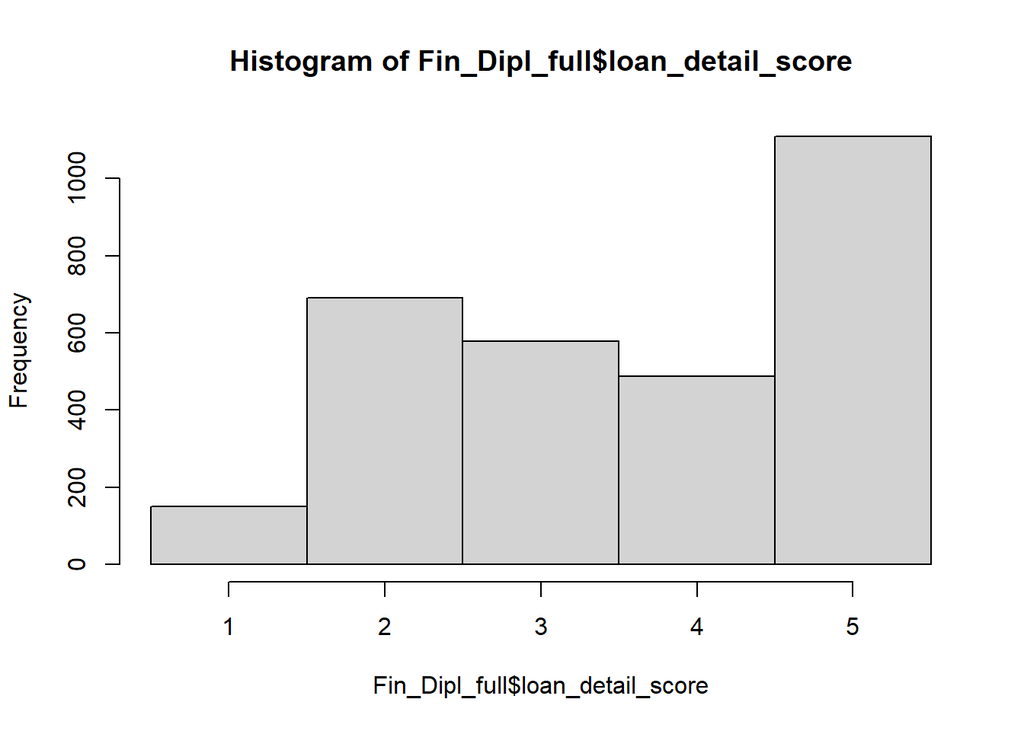

```r
# histogram of how detailed the loan information is
hist(Fin_Dipl_full$loan_detail_score, breaks = 0.5:5.5)
```

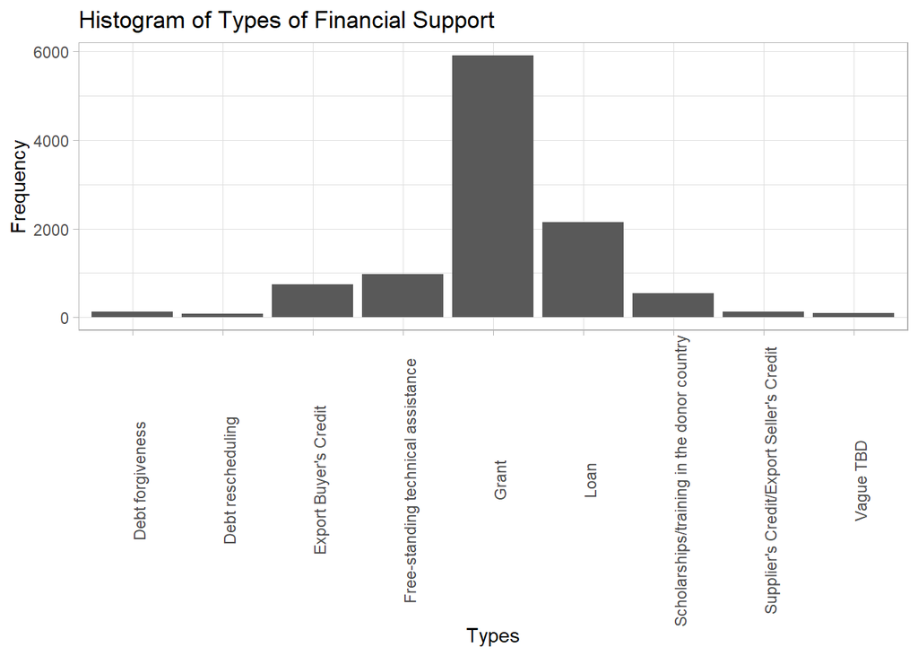

```r
# histogram of types of financial diplomacy
ggplot(Fin_Dipl_full, aes(x=flow_type)) +
  labs(title = "Histogram of Types of Financial Support", x = "Types",
       y = "Frequency") +
  geom_bar() +
  theme_light() +
  theme(axis.text.x = element_text(angle = 90))
```

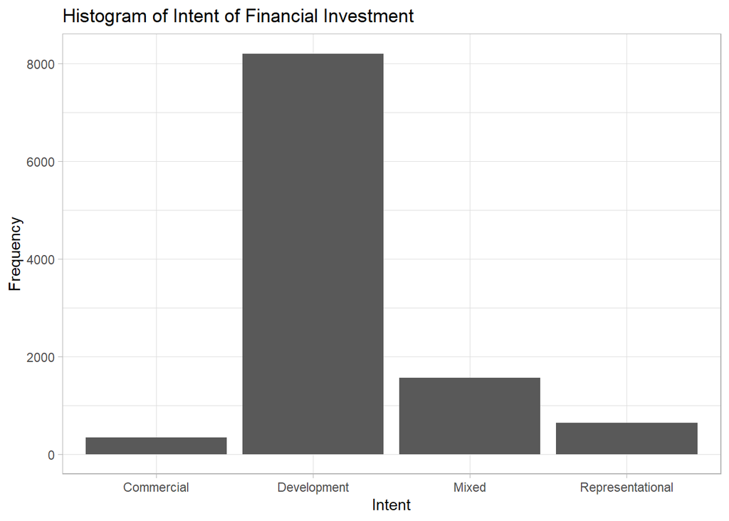

```r
# histogram of the intent for financial diplomacy
ggplot(Fin_Dipl_full, aes(x=intent)) +
  labs(title = "Histogram of Intent of Financial Investment", x = "Intent",
       y = "Frequency") +
  geom_bar() +
  theme_light()
```

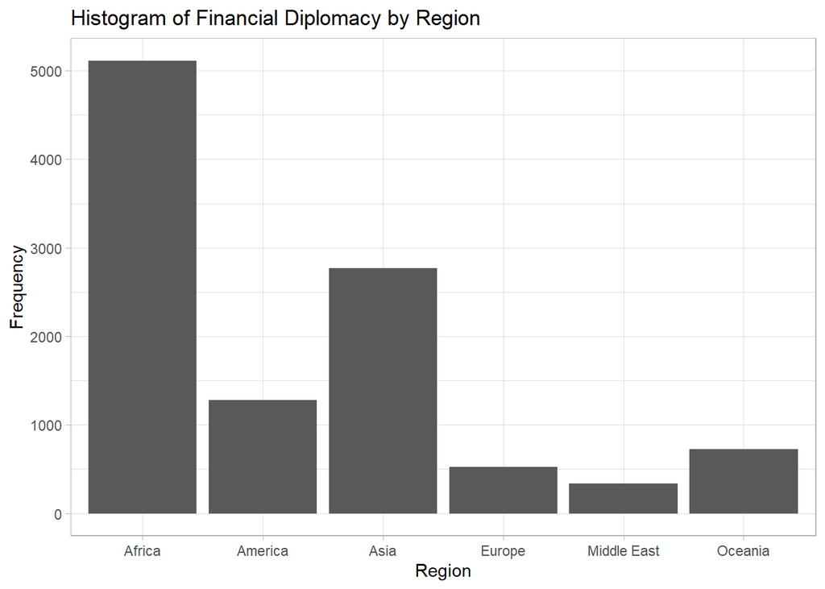

```r
# histogram of the region receiving financial diplomacy
ggplot(Fin_Dipl_full, aes(x=recipient_region)) +
  labs(title = "Histogram of Financial Diplomacy by Region", x = "Region",
       y = "Frequency") +
  geom_bar() +
  theme_light()
```

It seems that there are a few countries that have gotten the most from China. We will do further analysis to name which ones.

```r
# most frequent country
names(which.max(table(Fin_Dipl_full$recipient)))
```

```
## [1] "Angola"
```

Angola is the most frequent.

```r
# most frequently invested sector
names(which.max(table(Fin_Dipl_full$sector_name)))
```

```
## [1] "Education"
```

Education is the most frequently invested.

```r
# top 10 most frequent countries
sort(table(Fin_Dipl_full$recipient), decreasing = TRUE)[1:10]
```

```
##
##    Angola  Cambodia   Myanmar     Sudan  Pakistan Indonesia  DR Congo      Laos
##       318       261       241       231       225       224       205       203
##  Ethiopia  Tanzania
##       174       167
```

The top 10 countries are Angola, Cambodia, Myanmar, Sudan, Pakistan, Indonesia, the Democratic Republic of the Congo, Laos, Ethiopia, and Tanzania.

```r
# top 10 most frequent sectors
sort(table(Fin_Dipl_full$sector_name), decreasing = TRUE)[1:10]
```

```
##
##                                Education
##                                     1687
##                                   Health
##                                     1440
##             Government and Civil Society
##                                     1247
##                    Transport and Storage
##                                      998
##                                   Energy
##                                      867
##                       Emergency Response
##                                      835
## Other Social Infrastructure and Services
##                                      744
##           Agriculture, Forestry, Fishing
##                                      585
##           Industry, Mining, Construction
##                                      546
##                           Communications
##                                      489
```

## Diplomacy: UN Agreement

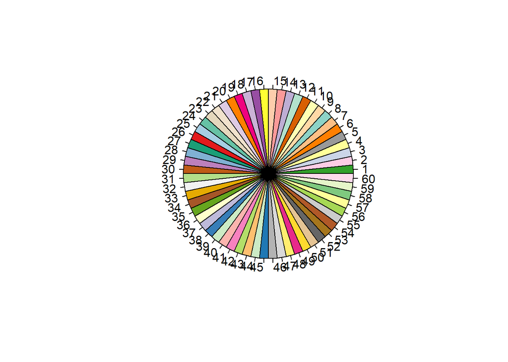

```r
# subset for specific Africa and South America regions
UN_geo <- merge(world, UN_Agree, by.x = "iso_a3", by.y = "Code", all.x = TRUE)

UN_geo_Africa <- subset(UN_geo, continent == "Africa")
UN_geo_SAmerica <- subset(UN_geo, continent == "South America")

UN_geo_WAfrica <- subset(UN_geo_Africa, subregion == "Western Africa")
UN_geo_SAfrica <- subset(UN_geo_Africa, subregion == "Southern Africa")
UN_geo_MAfrica <- subset(UN_geo_Africa, subregion == "Middle Africa")
UN_geo_EAfrica <- subset(UN_geo_Africa, subregion == "Eastern Africa")
UN_geo_NAfrica <- subset(UN_geo_Africa, subregion == "Northern Africa")

# large color palette creation
n <- 60
qual_col_pals = brewer.pal.info[brewer.pal.info$category == 'qual',]
col_vector = unlist(mapply(brewer.pal, qual_col_pals$maxcolors, rownames(qual_col_pals)))
pie(rep(1,n), col=sample(col_vector, n))
```

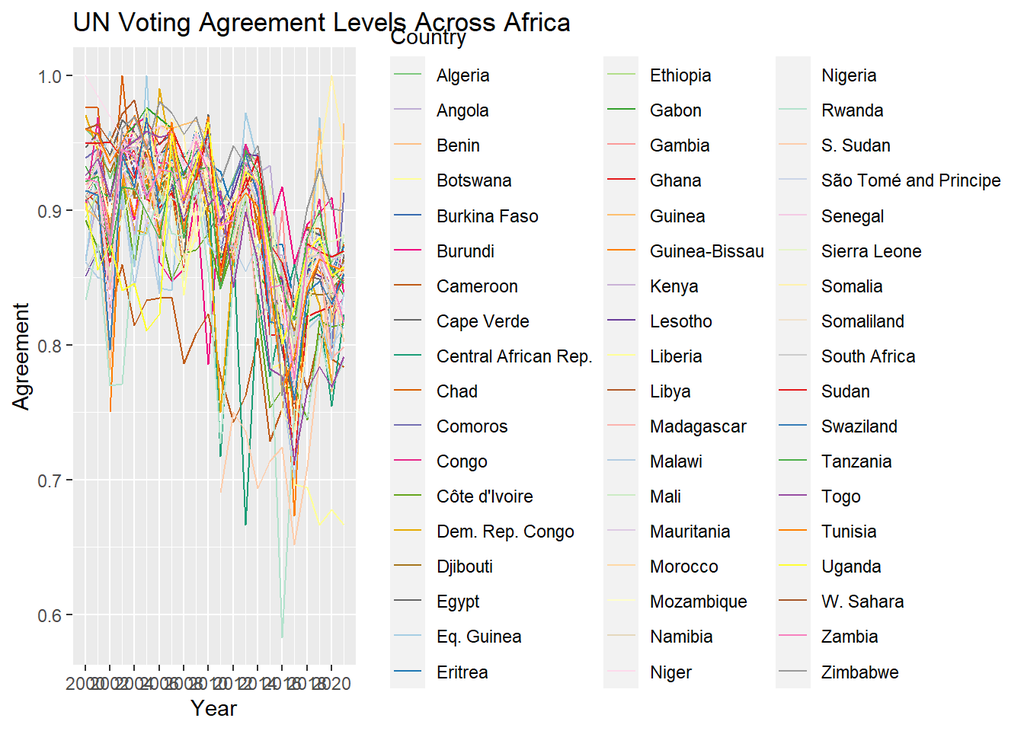

```r
color = grDevices::colors()[grep('gr(a|e)y', grDevices::colors(), invert = T)]

# line graph of UN agreement over time for Africa
ggplot(data = UN_geo_Africa, aes(x = Year, y = UN.Agreement, color = name)) +
  geom_line() +
  scale_color_manual(values = col_vector, name = "Country") +
  scale_x_continuous(breaks=seq(2000, 2021, 2)) +
  labs(title = "UN Voting Agreement Levels Across Africa", x = "Year", y = "Agreement")
```

[figure not shown]

```r
# repeat for Western Africa
WAfrica_UN <- ggplot(data = UN_geo_WAfrica, aes(x = Year, y = UN.Agreement, color = name)) +
  geom_line() +
  scale_color_manual(values = col_vector, name = "Country") +
  scale_x_continuous(breaks=seq(2000, 2021, 2)) +
  labs(title = "UN Voting Agreement Levels in Western Africa", x = "Year", y = "Agreement")

# repeat for Southern Africa
SAfrica_UN <- ggplot(data = UN_geo_SAfrica, aes(x = Year, y = UN.Agreement, color = name)) +
  geom_line() +
  scale_color_manual(values = col_vector, name = "Country") +
  scale_x_continuous(breaks=seq(2000, 2021, 2)) +
  labs(title = "UN Voting Agreement Levels in Southern Africa", x = "Year", y = "Agreement")

# repeat for Middle Africa
MAfrica_UN <- ggplot(data = UN_geo_MAfrica, aes(x = Year, y = UN.Agreement, color = name)) +
  geom_line() +
  scale_color_manual(values = col_vector, name = "Country") +
  scale_x_continuous(breaks=seq(2000, 2021, 2)) +
  labs(title = "UN Voting Agreement Levels in Middle Africa", x = "Year", y = "Agreement")

# repeat for Eastern Africa
EAfrica_UN <- ggplot(data = UN_geo_EAfrica, aes(x = Year, y = UN.Agreement, color = name)) +
  geom_line() +
  scale_color_manual(values = col_vector, name = "Country") +
  scale_x_continuous(breaks=seq(2000, 2021, 2)) +
  labs(title = "UN Voting Agreement Levels in Eastern Africa", x = "Year", y = "Agreement")

# repeat for Northern Africa
NAfrica_UN <- ggplot(data = UN_geo_NAfrica, aes(x = Year, y = UN.Agreement, color = name)) +
  geom_line() +
  scale_color_manual(values = col_vector, name = "Country") +
  scale_x_continuous(breaks=seq(2000, 2021, 2)) +
  labs(title = "UN Voting Agreement Levels in Northern Africa", x = "Year", y = "Agreement")

# tile the African subregions together
grid.arrange(WAfrica_UN, SAfrica_UN, MAfrica_UN, EAfrica_UN, NAfrica_UN, nrow = 2)
```

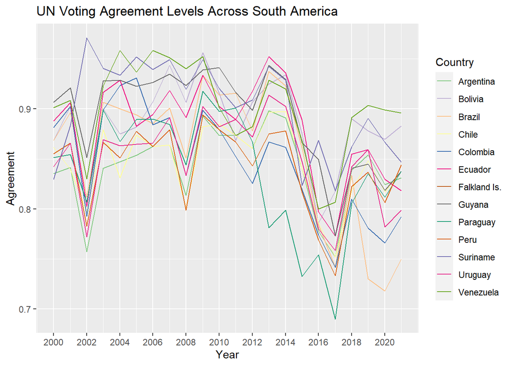

```r
# repeat for South America
ggplot(data = UN_geo_SAmerica, aes(x = Year, y = UN.Agreement, color = name)) +
  geom_line() +
  scale_color_manual(values = col_vector, name = "Country") +
  scale_x_continuous(breaks=seq(2000, 2021, 2)) +
  labs(title = "UN Voting Agreement Levels Across South America", x = "Year", y = "Agreement")
```

Now we can look at analyses.

```r
# averages across all years for each country in South America in new dataframe
avg_SAmerica_UN <- UN_geo_SAmerica  %>%
  st_drop_geometry() %>%
  group_by(name) %>%
  summarise_at(vars(UN.Agreement), list(name = mean))
avg_SAmerica_UN <- data.frame(unique(UN_geo_SAmerica$name), avg_SAmerica_UN)
colnames(avg_SAmerica_UN) <- c("Country", "Average Agreement")
avg_SAmerica_UN[!is.na(avg_SAmerica_UN$`Average Agreement`),]
```

```
##      Country Average Agreement
## 1  Argentina         0.8420204
## 2    Bolivia         0.8860322
## 3     Brazil         0.8561581
## 4      Chile         0.8457502
## 5   Colombia         0.8458334
## 6    Ecuador         0.8810368
## 8     Guyana         0.8928615
## 9       Peru         0.8371809
## 10  Paraguay         0.8411901
## 11  Suriname         0.9021081
## 12   Uruguay         0.8499571
## 13 Venezuela         0.9013645
```

```r
# averages across all years for each country in Africa in new dataframe
avg_Africa_UN <- UN_geo_Africa  %>%
  st_drop_geometry() %>%
  group_by(name) %>%
  summarise_at(vars(UN.Agreement), list(name = mean))
avg_Africa_UN <- data.frame(unique(UN_geo_Africa$name), avg_Africa_UN)
colnames(avg_Africa_UN) <- c("Country", "Average Agreement")
avg_Africa_UN[!is.na(avg_Africa_UN$`Average Agreement`),]
```

```
##                 Country Average Agreement
## 1                Angola         0.9125339
## 2               Burundi         0.8914197
## 3                 Benin         0.8804698
## 4          Burkina Faso         0.8742052
## 5              Botswana         0.8972230
## 6  Central African Rep.         0.8869572
## 7         Côte d'Ivoire         0.8070873
## 8              Cameroon         0.8837869
## 9       Dem. Rep. Congo         0.8555567
## 10                Congo         0.8968011
## 11              Comoros         0.9025121
## 12           Cape Verde         0.9016725
## 13             Djibouti         0.8454190
## 14              Algeria         0.8807434
```

[output cut: 37 more lines]

## Diplomacy: IGO Participation

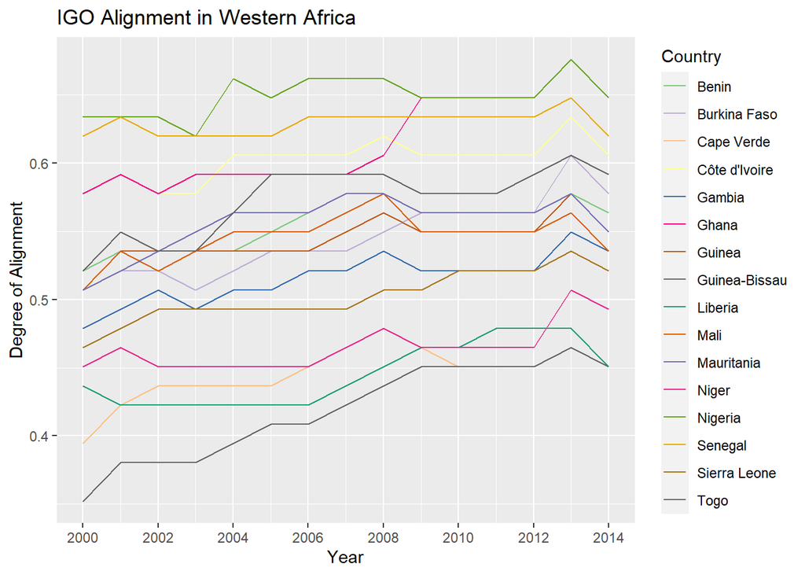

```r
# subset for specific Africa and South America regions
IGO_geo <- merge(world, IGO, by.x = "iso_a3", by.y = "Code", all.x = TRUE)

IGO_geo_Africa <- subset(IGO_geo, continent == "Africa")
IGO_geo_SAmerica <- subset(IGO_geo, continent == "South America")

IGO_geo_WAfrica <- subset(IGO_geo_Africa, subregion == "Western Africa")
IGO_geo_SAfrica <- subset(IGO_geo_Africa, subregion == "Southern Africa")
IGO_geo_MAfrica <- subset(IGO_geo_Africa, subregion == "Middle Africa")
IGO_geo_EAfrica <- subset(IGO_geo_Africa, subregion == "Eastern Africa")
IGO_geo_NAfrica <- subset(IGO_geo_Africa, subregion == "Northern Africa")

# Western Africa and China IGO Alignment
ggplot(IGO_geo_WAfrica, aes(x = Year, y = IGO.Alignment, color = name)) +
  geom_line() +
  scale_color_manual(values = col_vector, name = "Country") +
  scale_x_continuous(breaks=seq(2000, 2014, 2)) +
  labs(title = "IGO Alignment in Western Africa", x = "Year", y = "Degree of Alignment")
```

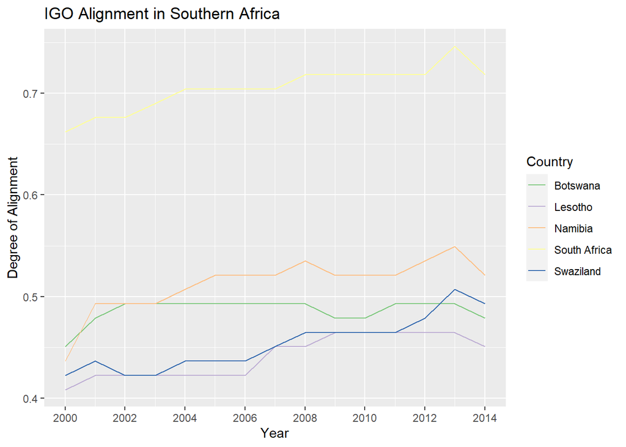

```r
# Southern Africa and China IGO Alignment
ggplot(IGO_geo_SAfrica, aes(x = Year, y = IGO.Alignment, color = name)) +
  geom_line() +
  scale_color_manual(values = col_vector, name = "Country") +
  scale_x_continuous(breaks=seq(2000, 2014, 2)) +
  labs(title = "IGO Alignment in Southern Africa", x = "Year", y = "Degree of Alignment")
```

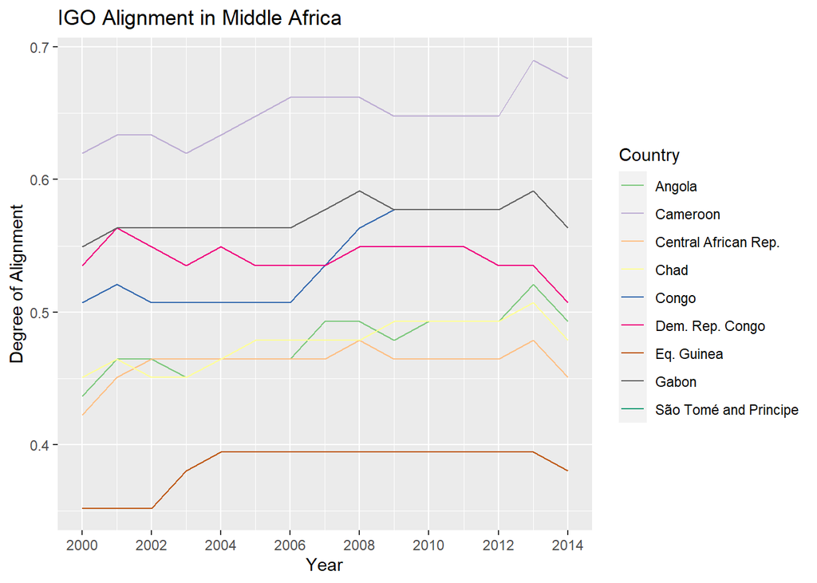

```r
# Middle Africa and China IGO Alignment
ggplot(IGO_geo_MAfrica, aes(x = Year, y = IGO.Alignment, color = name)) +
  geom_line() +
  scale_color_manual(values = col_vector, name = "Country") +
  scale_x_continuous(breaks=seq(2000, 2014, 2)) +
  labs(title = "IGO Alignment in Middle Africa", x = "Year", y = "Degree of Alignment")
```

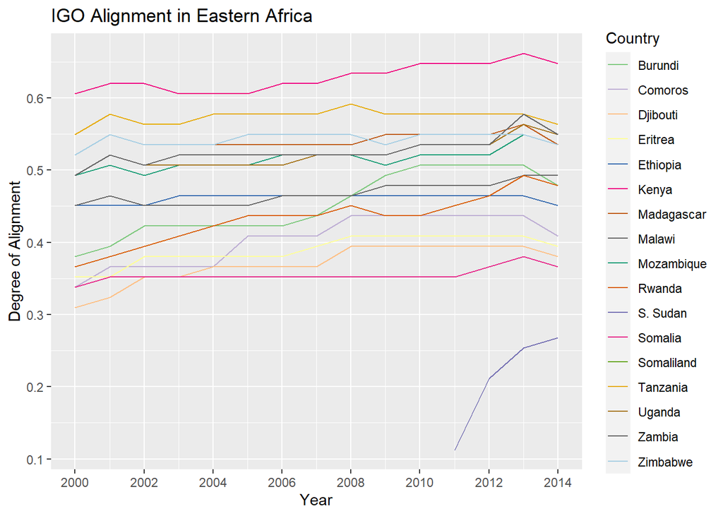

```r
# Eastern Africa and China IGO Alignment
ggplot(IGO_geo_EAfrica, aes(x = Year, y = IGO.Alignment, color = name)) +
  geom_line() +
  scale_color_manual(values = col_vector, name = "Country") +
  scale_x_continuous(breaks=seq(2000, 2014, 2)) +
  labs(title = "IGO Alignment in Eastern Africa", x = "Year", y = "Degree of Alignment")
```